# Estimación del modelo lineal

Sergio Olmos Pardo

14/3/2017

# Ejercicios del libro de Faraway

## Capítulo 2

### 1.

Cargamos el conjunto de datos `teengamb` en R y ajustamos un modelo lineal con el gasto en el juego como variable respuesta y sexo, estatus, salario y puntuación verbal como predictores.

```r
data(teengamb, package = "faraway")
head(teengamb)
```

```
##   sex status income verbal gamble
## 1   1     51   2.00      8    0.0
## 2   1     28   2.50      8    0.0
## 3   1     37   2.00      6    0.0
## 4   1     28   7.00      4    7.3
## 5   1     65   2.00      8   19.6
## 6   1     61   3.47      6    0.1
```

```r
teengamb_model <- lm(gamble ~ sex + status + income + verbal, data = teengamb)
(gamb_summary <- summary(teengamb_model))
```

```
##
## Call:
## lm(formula = gamble ~ sex + status + income + verbal, data = teengamb)
##
## Residuals:
##     Min      1Q  Median      3Q     Max
## -51.082 -11.320  -1.451   9.452  94.252
##
## Coefficients:
##              Estimate Std. Error t value Pr(>|t|)
## (Intercept)  22.55565   17.19680   1.312   0.1968
## sex         -22.11833    8.21111  -2.694   0.0101 *
## status        0.05223    0.28111   0.186   0.8535
## income        4.96198    1.02539   4.839 1.79e-05 ***
## verbal       -2.95949    2.17215  -1.362   0.1803
## ---
## Signif. codes:  0 '***' 0.001 '**' 0.01 '*' 0.05 '.' 0.1 ' ' 1
##
## Residual standard error: 22.69 on 42 degrees of freedom
## Multiple R-squared:  0.5267, Adjusted R-squared:  0.4816
## F-statistic: 11.69 on 4 and 42 DF,  p-value: 1.815e-06
```

#### (a)

```r
gamb_summary$adj.r.squared
```

```
## [1] 0.4816495
```

#### (b)

Accedemos al vector con los residuos del modelo y obtenemos el valor máximo (positivo).

```r
res <- gamb_summary$residuals
names(which.max(res))
```

```
## [1] "24"
```

El número de caso correspondiente al residuo mayor es el 24.

#### (c)

La media y la mediana de los residuales son:

```r
mean(res)
```

```
## [1] -3.065293e-17
```

```r
median(res)
```

```
## [1] -1.451392
```

#### (d)

La correlación entre los residuales y los valores ajustados es prácticamente 0.

```r
gambling_fitted <- fitted(teengamb_model)
cor(res, gambling_fitted)
```

```
## [1] -1.070659e-16
```

#### (e)

La correlación entre los residuos y los valores de `income` es

```r
cor(res, teengamb$income)
```

```
## [1] -7.242382e-17
```

#### (f)

El coeficiente para la variable `sex` es

```r
(coeff <- coef(teengamb_model))
```

```
##  (Intercept)          sex       status       income       verbal
##  22.55565063 -22.11833009   0.05223384   4.96197922  -2.95949350
```

El modelo predice que una mujer gastará alrededor de 22 libras menos que un hombre, manteniendo el resto de predictores iguales.

### 2.

Cargamos el conjunto de datos `uswages` y ajustamos un modelo lineal con salario semanal como respuesta y años de educación y experiencia como predictores:

```r
data(uswages, package = "faraway")
head(uswages)
```

```
##         wage educ exper race smsa ne mw so we pt
## 6085  771.60   18    18    0    1  1  0  0  0  0
## 23701 617.28   15    20    0    1  0  0  0  1  0
## 16208 957.83   16     9    0    1  0  0  1  0  0
## 2720  617.28   12    24    0    1  1  0  0  0  0
## 9723  902.18   14    12    0    1  0  1  0  0  0
## 22239 299.15   12    33    0    1  0  0  0  1  0
```

```r
uswages_model <- lm(wage ~ educ + exper, data = uswages)
summary(uswages_model)
```

```
##
## Call:
## lm(formula = wage ~ educ + exper, data = uswages)
##
## Residuals:
##     Min      1Q  Median      3Q     Max
## -1018.2  -237.9   -50.9   149.9  7228.6
##
## Coefficients:
##              Estimate Std. Error t value Pr(>|t|)
## (Intercept) -242.7994    50.6816  -4.791 1.78e-06 ***
## educ          51.1753     3.3419  15.313  < 2e-16 ***
## exper          9.7748     0.7506  13.023  < 2e-16 ***
## ---
## Signif. codes:  0 '***' 0.001 '**' 0.01 '*' 0.05 '.' 0.1 ' ' 1
##
## Residual standard error: 427.9 on 1997 degrees of freedom
## Multiple R-squared:  0.1351, Adjusted R-squared:  0.1343
## F-statistic:   156 on 2 and 1997 DF,  p-value: < 2.2e-16
```

Según este modelo, a misma experiencia, por cada año de educación que haya cursado un sujeto su salario semanal aumenta algo más de $50. Similarmente, a igual nivel de educación, por cada año de experiencia su salario semanal aumenta casi $10.

El modelo alternativo es el mismo pero tomando el logaritmo de la respuesta:

```r
log_model <- lm(log(wage) ~ educ + exper, data = uswages)
summary(log_model)
```

```
##
## Call:
## lm(formula = log(wage) ~ educ + exper, data = uswages)
##
## Residuals:
##     Min      1Q  Median      3Q     Max
## -2.7533 -0.3495  0.1068  0.4381  3.5699
##
## Coefficients:
##             Estimate Std. Error t value Pr(>|t|)
## (Intercept) 4.650319   0.078354   59.35   <2e-16 ***
## educ        0.090506   0.005167   17.52   <2e-16 ***
## exper       0.018079   0.001160   15.58   <2e-16 ***
## ---
## Signif. codes:  0 '***' 0.001 '**' 0.01 '*' 0.05 '.' 0.1 ' ' 1
##
## Residual standard error: 0.6615 on 1997 degrees of freedom
## Multiple R-squared:  0.1749, Adjusted R-squared:  0.174
## F-statistic: 211.6 on 2 and 1997 DF,  p-value: < 2.2e-16
```

En este caso un año de educación aumenta 0.09 el logaritmo natural del salario semanal y un año de experiencia aumenta 0.02 el logaritmo natural del salario semanal.

Está claro que el primer modelo es más fácil de interpretar.

### 4.

El conjunto de datos es

```r
data(prostate, package = "faraway")
head(prostate)
```

```
##       lcavol lweight age      lbph svi      lcp gleason pgg45     lpsa
## 1 -0.5798185  2.7695  50 -1.386294   0 -1.38629       6     0 -0.43078
## 2 -0.9942523  3.3196  58 -1.386294   0 -1.38629       6     0 -0.16252
## 3 -0.5108256  2.6912  74 -1.386294   0 -1.38629       7    20 -0.16252
## 4 -1.2039728  3.2828  58 -1.386294   0 -1.38629       6     0 -0.16252
## 5  0.7514161  3.4324  62 -1.386294   0 -1.38629       6     0  0.37156
## 6 -1.0498221  3.2288  50 -1.386294   0 -1.38629       6     0  0.76547
```

Partiendo del modelo lineal con `lpsa` como variable respuesta y `lcavol` como único predictor, iremos añadiendo las otras 7 de variables y anotando el error típico residual y las $R^2$.

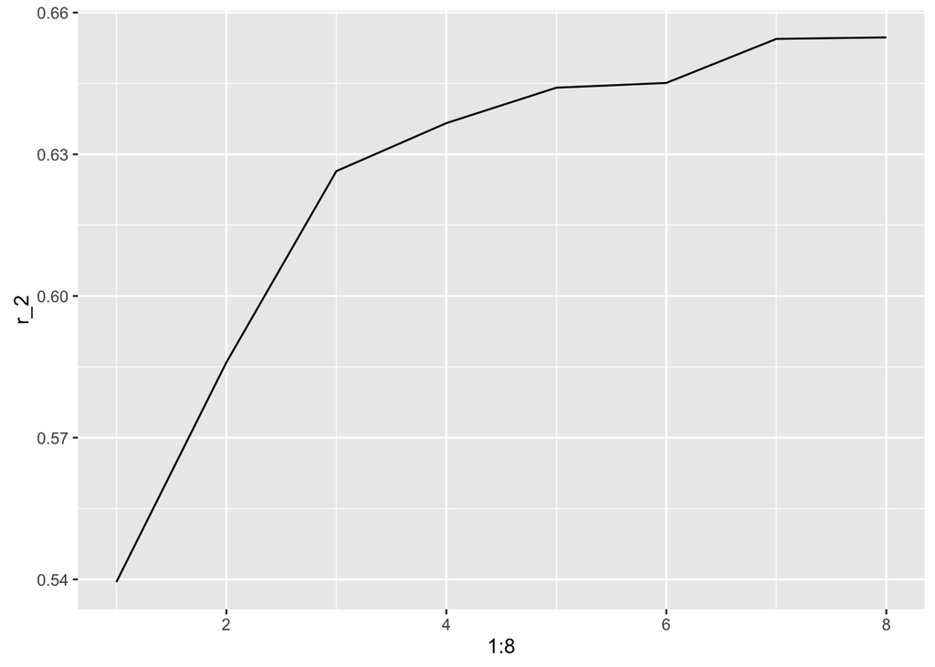

```r
m1 <- summary(lm(lpsa ~ lcavol, data = prostate))
m2 <- summary(lm(lpsa ~ lcavol + lweight, data = prostate))
m3 <- summary(lm(lpsa ~ lcavol + lweight + svi, data = prostate))
m4 <- summary(lm(lpsa ~ lcavol + lweight + svi +
                         lbph, data = prostate))
m5 <- summary(lm(lpsa ~ lcavol + lweight + svi +
                         lbph + age, data = prostate))
m6 <- summary(lm(lpsa ~ lcavol + lweight + svi +
                         lbph + age + lcp, data = prostate))
m7 <- summary(lm(lpsa ~ lcavol + lweight + svi +
                         lbph + age + lcp + pgg45, data = prostate))
m8 <- summary(lm(lpsa ~ lcavol + lweight + svi +
                         lbph + age + lcp + pgg45 + gleason, data = prostate))
r_2 <- c(m1$r.squared, m2$r.squared, m3$r.squared,
         m4$r.squared, m5$r.squared, m6$r.squared,
         m7$r.squared, m8$r.squared)
se <- c(m1$sigma, m2$sigma, m3$sigma, m4$sigma,
        m5$sigma, m6$sigma, m7$sigma, m8$sigma)

library(ggplot2)
ggplot(data = as.data.frame(r_2)) + geom_path(mapping = aes(x = 1:8, y = r_2))
```

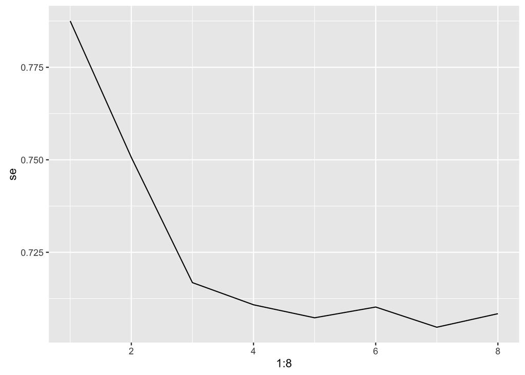

```r
ggplot(data = as.data.frame(se)) + geom_path(mapping = aes(x = 1:8, y = se))
```

Los gráficos sugieren que bastaría con el model `m3`.

### 5.

Utilizando el conjunto de datos del ejercicio anterior, crearemos un diagrama de dispersión de `lpsa` contra `lcalvol` e incluiremos las lineas de regresión obtenidas de `lpsa ~ lcalvol` y `lcalvol ~ lpsa`.

```r
mod1 <- lm(lpsa ~ lcavol, data = prostate)
mod2 <- lm(lcavol ~ lpsa, data = prostate)
```

Queremos hayar las dos lineas de regresión resultantes de ajustar los modelos `lpsa ~ lcavol` y `lcavol ~ lpsa`. Obtenemos los coeficientes de los dos modelos.

```r
(coef_mod1 <- coef(mod1))
```

```
## (Intercept)      lcavol
##   1.5072979   0.7193201
```

```r
(coef_mod2 <- coef(mod2))
```

```
## (Intercept)        lpsa
##  -0.5085802   0.7499191
```

Dejemos que $y$ sea `lpsa`, $x$ sea `lcavol`. Luego las ecuaciones de las lineas de regresión vienes dadas por $y = \beta_0 + \beta_1 x$ para el primer modelo y $x = \alpha_0 + \alpha_1 y$, donde $\beta_i$ y $\alpha_i$ son los correspondientes parámetros del modelo.

Para poder mostrar la recta correspondiente al modelo `lcavol ~ lpsa` en nuestra gráfica manipulamos la ecuación de la segunda linea de regresión y obtenemos que
$$y = - \frac{\alpha_0}{\alpha_1} + \frac{1}{\alpha_1} x$$
De modo que la pendiente y la intercepción serían

```r
mod2_slope <- 1 / mod2$coefficients[2]
mod2_intercept <- - mod2$coefficients[1] / mod2$coefficients[2]
```

Obtenemos la gráfica de la siguiente manera

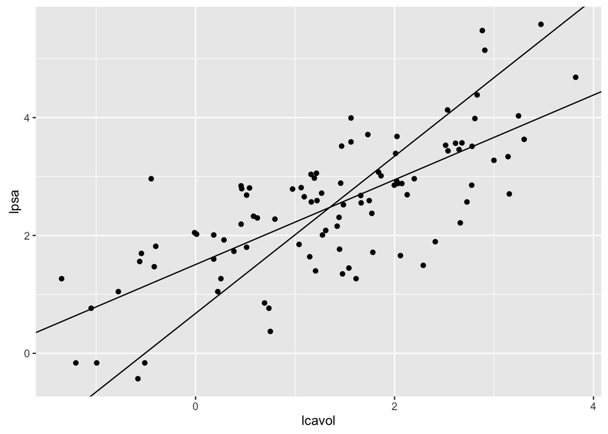

```r
ggplot(data = prostate, mapping = aes(x = lcavol, y = lpsa)) +
        geom_point() +
        geom_abline(slope = mod1$coefficients[2], intercept = mod1$coefficients[1]) +
        geom_abline(slope = mod2_slope, intercept = mod2_intercept)
```

Ahora obtendremos el punto en el que las dos rectas se cruzan. Podemos hayar este punto algebraicamente resolviendo la ecuación
$$\begin{aligned}
\beta_1 x + \beta_0 &= \alpha_1 ^* x + \alpha_0 ^* \\
x(\beta_1 - \alpha_1 ^*) &= \alpha_0 ^* - \beta_0 \\
x &= \frac{\alpha_0 ^* - \beta_0}{\beta_1 - \alpha_1 ^*}
\end{aligned}$$

Utilizaremos R para obtener los valores de `lpsa` y `lcavol` donde las dos rectas se cruzan.

```r
mod1_slope <- mod1$coefficients[2]
mod1_intercept <- mod1$coefficients[1]
x <- (mod2_intercept - mod1_intercept) / (mod1_slope - mod2_slope)
x <- unname(x)
y <- mod1_slope * x + mod1_intercept
y <- unname(y)
intersection <- c(lpsa = x, lcavol = y)
intersection
```

[output not shown]

### 6.

El conjunto de datos es el siguiente

```r
data(cheddar, package = "faraway")
head(cheddar)
```

```
##   taste Acetic   H2S Lactic
## 1  12.3  4.543 3.135   0.86
## 2  20.9  5.159 5.043   1.53
## 3  39.0  5.366 5.438   1.57
## 4  47.9  5.759 7.496   1.81
## 5   5.6  4.663 3.807   0.99
## 6  25.9  5.697 7.601   1.09
```

#### (a)

Los coeficientes del modelo con `taste` como respuesta y los tres contenidos químicos como predictores son

```r
cheddar_model <- lm(taste ~ Acetic + H2S + Lactic, data = cheddar)
summary(cheddar_model)
```

```
##
## Call:
## lm(formula = taste ~ Acetic + H2S + Lactic, data = cheddar)
##
## Residuals:
##     Min      1Q  Median      3Q     Max
## -17.390  -6.612  -1.009   4.908  25.449
##
## Coefficients:
##             Estimate Std. Error t value Pr(>|t|)
## (Intercept) -28.8768    19.7354  -1.463  0.15540
## Acetic        0.3277     4.4598   0.073  0.94198
## H2S           3.9118     1.2484   3.133  0.00425 **
## Lactic       19.6705     8.6291   2.280  0.03108 *
## ---
## Signif. codes:  0 '***' 0.001 '**' 0.01 '*' 0.05 '.' 0.1 ' ' 1
##
## Residual standard error: 10.13 on 26 degrees of freedom
## Multiple R-squared:  0.6518, Adjusted R-squared:  0.6116
## F-statistic: 16.22 on 3 and 26 DF,  p-value: 3.81e-06
```

```r
coefficients(cheddar_model)
```

```
## (Intercept)      Acetic         H2S      Lactic
## -28.8767696   0.3277413   3.9118411  19.6705434
```

#### (b)

La correlación entre los valores ajustados y la respuesta.

```r
cor(fitted(cheddar_model), cheddar$taste) ^ 2
```

```
## [1] 0.6517747
```

Este valor corresponde al valor de $R^2$ del modelo.

```r
summary(cheddar_model)$r.squared
```

```
## [1] 0.6517747
```

#### (c)

Ajustaremos el mismo modelo pero sin termino de intercepción.

```r
cheddar_no_intercept <- lm(taste ~ 0 + Acetic + H2S + Lactic, data = cheddar)
summary(cheddar_no_intercept)
```

```
##
## Call:
## lm(formula = taste ~ 0 + Acetic + H2S + Lactic, data = cheddar)
##
## Residuals:
##      Min       1Q   Median       3Q      Max
## -15.4521  -6.5262  -0.6388   4.6811  28.4744
##
## Coefficients:
##        Estimate Std. Error t value Pr(>|t|)
## Acetic   -5.454      2.111  -2.583  0.01553 *
## H2S       4.576      1.187   3.854  0.00065 ***
## Lactic   19.127      8.801   2.173  0.03871 *
## ---
## Signif. codes:  0 '***' 0.001 '**' 0.01 '*' 0.05 '.' 0.1 ' ' 1
##
## Residual standard error: 10.34 on 27 degrees of freedom
## Multiple R-squared:  0.8877, Adjusted R-squared:  0.8752
## F-statistic: 71.15 on 3 and 27 DF,  p-value: 6.099e-13
```

Otra medida de bondad de ajuste es el error típico residual que viene dado por:

```r
summary(cheddar_no_intercept)$sigma
```

```
## [1] 10.34254
```

Cuanto menor sea esta cantidad mejor se ajusta el modelo.

#### (d)

Primero creamos la matriz $\textbf X$ y el vector $\textbf y$:

```r
x <- model.matrix( ~ Acetic + H2S + Lactic, data = cheddar)
y <- cheddar$taste
```

Realizamos la descomposición QR:

```r
qrx <- qr(x)
```

Usando `qr.q()` para calcular $Q_f$ podemos obtener $f$:

```r
f <- t(qr.Q(qrx)) %*% y
```

Y ahora resolvemos $R \beta = f$:

```r
backsolve(qr.R(qrx), f)
```

```
##             [,1]
## [1,] -28.8767696
## [2,]   0.3277413
## [3,]   3.9118411
## [4,]  19.6705434
```

Que se corresponden con los coeficientes obtenidos en el apartado (a).